# Lab 12

Author

Jess Ho

```r
library(neonUtilities)
library(tidyverse)
library(lubridate)
library(DT)
library(viridis)
library(janitor)
library(plotly)
```

```r
soilChem <- readRDS("/work/pi_bio678_umass_edu/data_NEON/soilChem.rds")
```

```r
soilChem$sls_metagenomicsPooling[5,'genomicsSampleID']
```

```
[1] "HARV_013-O-20230704-COMP"
```

```r
soilChem$sls_metagenomicsPooling[5,'collectDate']
```

```
[1] "2023-07-04 19:03:00 UTC"
```

```r
soilChem$sls_metagenomicsPooling$genomicsPooledIDList[5]
```

```
[1] "HARV_013-O-39-20230704|HARV_013-O-41-20230704|HARV_013-O-23-20230704"
```

```r
soilChem$sls_soilMoisture |>
  filter(sampleID == "HARV_013-O-39-20230704") |>
  select(sampleID, soilMoisture)
```

```
                sampleID soilMoisture
1 HARV_013-O-39-20230704        3.223
```

```r
genomicSamples <- soilChem$sls_metagenomicsPooling |>
  tidyr::separate(genomicsPooledIDList, into=c("first","second","third"),sep="\\|",fill="right") |>
  dplyr::select(genomicsSampleID,first,second,third)

head(genomicSamples)
```

```
          genomicsSampleID                  first                 second
1 HARV_034-O-20230703-COMP HARV_034-O-23-20230703 HARV_034-O-41-20230703
2 HARV_033-O-20230703-COMP HARV_033-O-39-20230703 HARV_033-O-21-20230703
3 HARV_035-O-20230704-COMP HARV_035-O-23-20230704 HARV_035-O-41-20230704
4 HARV_037-O-20230704-COMP HARV_037-O-41-20230704 HARV_037-O-21-20230704
5 HARV_013-O-20230704-COMP HARV_013-O-39-20230704 HARV_013-O-41-20230704
6 HARV_001-O-20230705-COMP HARV_001-O-41-20230705 HARV_001-O-21-20230705
                   third
1 HARV_034-O-39-20230703
2 HARV_033-O-41-20230703
3 HARV_035-O-21-20230704
4 HARV_037-O-23-20230704
5 HARV_013-O-23-20230704
6 HARV_001-O-23-20230705
```

```r
genSampleExample <- genomicSamples |>
  tidyr::pivot_longer(cols=c("first","second","third"),values_to = "sampleID") |>
  dplyr::select(sampleID,genomicsSampleID) |>
  drop_na()
```

```r
chemEx <- soilChem$sls_soilMoisture |>
  dplyr::select(sampleID,soilMoisture)

combinedTab <- left_join(genSampleExample,chemEx, by = "sampleID") |> drop_na()

head(combinedTab)
```

```
# A tibble: 6 × 3
  sampleID               genomicsSampleID         soilMoisture
  <chr>                  <chr>                           <dbl>
1 HARV_034-O-23-20230703 HARV_034-O-20230703-COMP         3.41
2 HARV_034-O-41-20230703 HARV_034-O-20230703-COMP         2.98
3 HARV_034-O-39-20230703 HARV_034-O-20230703-COMP         2.70
4 HARV_033-O-39-20230703 HARV_033-O-20230703-COMP         3.48
5 HARV_033-O-21-20230703 HARV_033-O-20230703-COMP         2.76
6 HARV_033-O-41-20230703 HARV_033-O-20230703-COMP         3.31
```

```r
genome_groups_mean <- combinedTab %>%
  group_by(genomicsSampleID) %>%
  summarize_at(c("soilMoisture"), mean)

head(genome_groups_mean)
```

```
# A tibble: 6 × 2
  genomicsSampleID         soilMoisture
  <chr>                           <dbl>
1 BONA_001-O-20230710-COMP         1.55
2 BONA_002-O-20230711-COMP         1.14
3 BONA_004-O-20230712-COMP         3.55
4 BONA_006-O-20230710-COMP         2.54
5 BONA_009-O-20230711-COMP         1.93
6 BONA_013-O-20230710-COMP         2.45
```

```r
soilpH_Example <- soilChem$sls_soilpH %>%
  dplyr::filter(sampleID %in% combinedTab$sampleID) %>%
  dplyr::select(sampleID,soilInWaterpH,soilInCaClpH)

combinedTab_pH <- left_join(combinedTab,soilpH_Example, by = "sampleID")

head(combinedTab_pH)
```

```
# A tibble: 6 × 5
  sampleID              genomicsSampleID soilMoisture soilInWaterpH soilInCaClpH
  <chr>                 <chr>                   <dbl>         <dbl>        <dbl>
1 HARV_034-O-23-202307… HARV_034-O-2023…         3.41          3.45         2.7
2 HARV_034-O-41-202307… HARV_034-O-2023…         2.98          3.28         2.6
3 HARV_034-O-39-202307… HARV_034-O-2023…         2.70          3.34         2.71
4 HARV_033-O-39-202307… HARV_033-O-2023…         3.48          3.85         3.04
5 HARV_033-O-21-202307… HARV_033-O-2023…         2.76          3.99         3.29
6 HARV_033-O-41-202307… HARV_033-O-2023…         3.31          3.63         2.84
```

```r
library(respirometry)

genome_groups_pH <- combinedTab_pH %>%
  group_by(genomicsSampleID) %>%
  summarize_at(c("soilInWaterpH","soilInCaClpH"), mean_pH)

head(genome_groups_pH)
```

```
# A tibble: 6 × 3
  genomicsSampleID         soilInWaterpH soilInCaClpH
  <chr>                            <dbl>        <dbl>
1 BONA_001-O-20230710-COMP          3.99         3.45
2 BONA_002-O-20230711-COMP          4.35         3.82
3 BONA_004-O-20230712-COMP          3.69         3.10
4 BONA_006-O-20230710-COMP          4.05         3.48
5 BONA_009-O-20230711-COMP          4.08         3.50
6 BONA_013-O-20230710-COMP          3.97         3.42
```

```r
genome_groups_all_mean <- combinedTab_pH %>%
  group_by(genomicsSampleID) %>%
  {left_join(
    summarize_at(.,vars("soilMoisture"), mean),
    summarize_at(.,vars("soilInWaterpH","soilInCaClpH"), mean_pH)
  )}

head(genome_groups_all_mean)
```

```
# A tibble: 6 × 4
  genomicsSampleID         soilMoisture soilInWaterpH soilInCaClpH
  <chr>                           <dbl>         <dbl>        <dbl>
1 BONA_001-O-20230710-COMP         1.55          3.99         3.45
2 BONA_002-O-20230711-COMP         1.14          4.35         3.82
3 BONA_004-O-20230712-COMP         3.55          3.69         3.10
4 BONA_006-O-20230710-COMP         2.54          4.05         3.48
5 BONA_009-O-20230711-COMP         1.93          4.08         3.50
6 BONA_013-O-20230710-COMP         2.45          3.97         3.42
```

## Exercises

### Exercise 1 - The dataframe sls_soilCoreCollection contains alot of useful information for analyzing the NEON MAGs. Create a new dataframe `coreCollectionSubset` with just the following columns

- sampleID
- decimalLatitude
- decimalLongitude
- elevation
- soilTemp

```r
coreCollectionSubset <- soilChem$sls_soilCoreCollection[, c("sampleID", "decimalLatitude", "decimalLongitude", "elevation", "soilTemp")]

head(coreCollectionSubset)
```

```
                sampleID decimalLatitude decimalLongitude elevation soilTemp
1 BART_002-O-23-20231002        44.03508        -71.27284     550.6     13.0
2 BART_002-O-21-20231002        44.03508        -71.27284     550.6     12.9
3 BART_002-O-39-20231002        44.03508        -71.27284     550.6     13.3
4 BART_001-O-41-20231002        44.04708        -71.30666     467.7     12.2
5 BART_001-O-23-20231002        44.04708        -71.30666     467.7     12.1
6 BART_001-O-21-20231002        44.04708        -71.30666     467.7     12.2
```

### Exercise 2 - Following the above examples with `chemEx` join `genSampleExample` and `coreCollectionSubset`.

```r
chemGenCore<- chemEx %>%
  inner_join(genSampleExample, by = "sampleID") %>%
  inner_join(coreCollectionSubset, by = "sampleID")

head(chemGenCore)
```

```
                sampleID soilMoisture         genomicsSampleID decimalLatitude
1 HARV_034-O-41-20230703        2.984 HARV_034-O-20230703-COMP        42.53569
2 HARV_034-O-23-20230703        3.407 HARV_034-O-20230703-COMP        42.53569
3 HARV_034-O-39-20230703        2.704 HARV_034-O-20230703-COMP        42.53569
4 HARV_033-O-39-20230703        3.479 HARV_033-O-20230703-COMP        42.53830
5 HARV_033-O-41-20230703        3.310 HARV_033-O-20230703-COMP        42.53830
6 HARV_033-O-21-20230703        2.755 HARV_033-O-20230703-COMP        42.53830
  decimalLongitude elevation soilTemp
1        -72.17797     372.1     14.6
2        -72.17797     372.1     14.9
3        -72.17797     372.1     14.1
4        -72.17561     358.8     15.7
5        -72.17561     358.8     15.2
6        -72.17561     358.8     15.8
```

### Exercise 3 - Get the mean for each mean for each metagenome `genomicsSampleID` for each column in your data frame from Ex. 2.

```r
chemGenCore %>%
  group_by(genomicsSampleID) %>%
  summarise(across(where(is.numeric), ~ mean(.x, na.rm = TRUE)))
```

```
# A tibble: 293 × 6
   genomicsSampleID      soilMoisture decimalLatitude decimalLongitude elevation
   <chr>                        <dbl>           <dbl>            <dbl>     <dbl>
 1 BONA_001-O-20230710-…         1.55            65.2            -147.      374.
 2 BONA_002-O-20230711-…         1.14            65.2            -148.      484.
 3 BONA_004-O-20230712-…         3.55            65.2            -148.      669.
 4 BONA_006-O-20230710-…         2.54            65.2            -148.      507
 5 BONA_009-O-20230711-…         1.93            65.2            -148.      430.
 6 BONA_013-O-20230710-…         2.45            65.2            -148.      540.
 7 BONA_070-O-20230712-…         3.06            65.2            -148.      238.
 8 BONA_071-O-20230711-…         1.39            65.2            -148.      246.
 9 BONA_080-O-20230713-…         2.86            65.2            -148.      242.
10 BONA_084-O-20230713-…         1.91            65.2            -148.      264.
# ℹ 283 more rows
# ℹ 1 more variable: soilTemp <dbl>
```

### Exercise 4 - Join the data frame from Ex. 3 with the soil moisture and pH measurments in `genome_groups_all_mean`.

```r
chemGenCore_withEnv <- chemGenCore %>%
  inner_join(genome_groups_all_mean %>%
               select(genomicsSampleID, soilMoisture, soilInWaterpH, soilInCaClpH),
             by = "genomicsSampleID")
head(chemGenCore_withEnv)
```

```
                sampleID soilMoisture.x         genomicsSampleID
1 HARV_034-O-41-20230703          2.984 HARV_034-O-20230703-COMP
2 HARV_034-O-23-20230703          3.407 HARV_034-O-20230703-COMP
3 HARV_034-O-39-20230703          2.704 HARV_034-O-20230703-COMP
4 HARV_033-O-39-20230703          3.479 HARV_033-O-20230703-COMP
5 HARV_033-O-41-20230703          3.310 HARV_033-O-20230703-COMP
6 HARV_033-O-21-20230703          2.755 HARV_033-O-20230703-COMP
  decimalLatitude decimalLongitude elevation soilTemp soilMoisture.y
1        42.53569        -72.17797     372.1     14.6       3.031667
2        42.53569        -72.17797     372.1     14.9       3.031667
3        42.53569        -72.17797     372.1     14.1       3.031667
4        42.53830        -72.17561     358.8     15.7       3.181333
5        42.53830        -72.17561     358.8     15.2       3.181333
6        42.53830        -72.17561     358.8     15.8       3.181333
  soilInWaterpH soilInCaClpH
1      3.351084     2.667091
2      3.351084     2.667091
3      3.351084     2.667091
4      3.797688     3.019192
5      3.797688     3.019192
6      3.797688     3.019192
```

### Exercise 5 - Using the `genomicsSampleID` column, make a new column with the siteID (e.g. HARV). There is a similar example in lab 6 where we parsed the NEON MAG data.

```r
chemGenCore_withEnv <- chemGenCore %>%
  mutate(siteID = sub("_.*", "", genomicsSampleID)) %>%
  inner_join(genome_groups_all_mean, by = "genomicsSampleID")
```

### Exercise 6 - Make a box plot with the soilpH by siteID

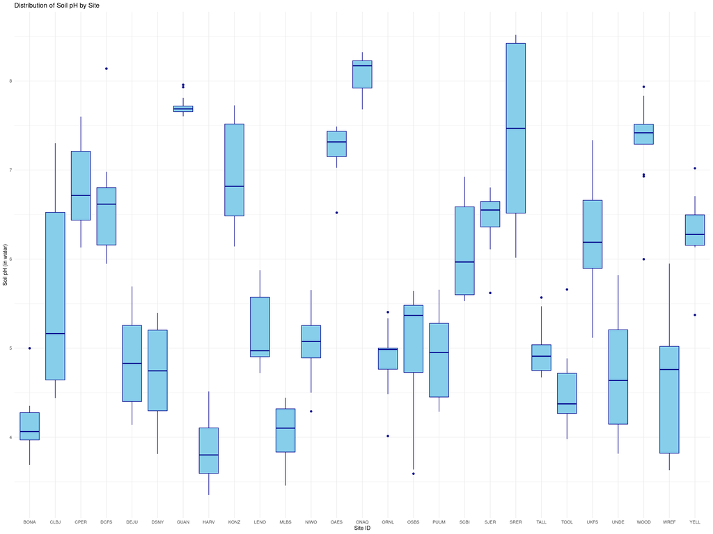

```r
ggplot(chemGenCore_withEnv, aes(x = siteID, y = soilInWaterpH)) +
  geom_boxplot(fill = "skyblue", color = "darkblue") +
  labs(
    title = "Distribution of Soil pH by Site",
    x = "Site ID",
    y = "Soil pH (in water)"
  ) +
  theme_minimal()
```

### Exercise 7 - Calculate the mean soilTemp and soilMoisture for each siteID. Make a graph of mean soilTemp vs soilMoisture

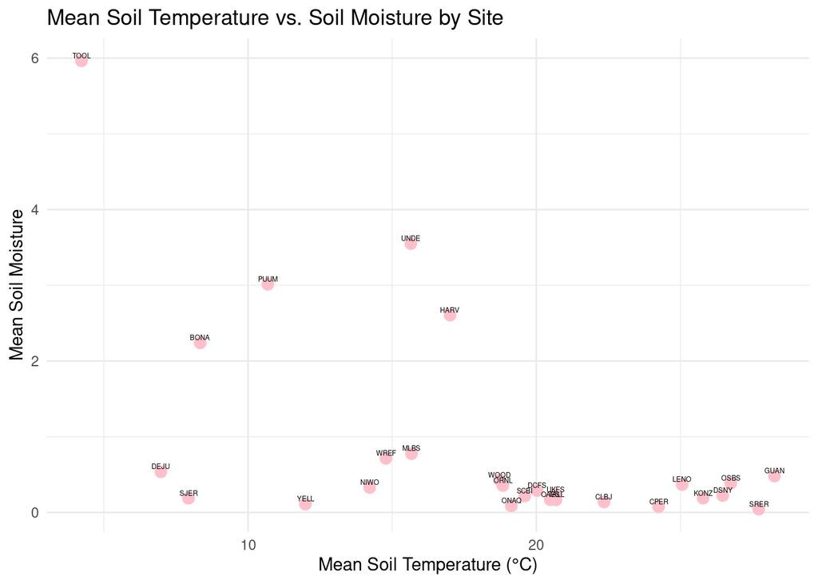

```r
site_means <- chemGenCore_withEnv %>%
  group_by(siteID) %>%
  summarise(
    mean_soilTemp = mean(soilTemp, na.rm = TRUE),
    mean_soilMoisture = mean(soilMoisture.y, na.rm = TRUE)
  )

ggplot(site_means, aes(x = mean_soilTemp, y = mean_soilMoisture, label = siteID)) +
  geom_point(color = "pink", size = 3) +
  geom_text(vjust = -0.5, size = 1.5) +
  labs(
    title = "Mean Soil Temperature vs. Soil Moisture by Site",
    x = "Mean Soil Temperature (°C)",
    y = "Mean Soil Moisture"
  ) +
  theme_minimal()
```

### Exercise 8 - Join your data frame from Ex 4 with the `NEON_MAGs_soil` data frame from lab 6.

```r
# This is the location used for Github
# This is the location used for the class data directory on Unity
NEON_MAGs_prelim <- read_tsv("/work/pi_bio678_umass_edu/data_NEON/exported_img_bins_Gs0166454_NEON.tsv") |>

  clean_names() |>

  # Add a new column community corresponding to different communities names in the genome_name
  mutate(community = case_when(
    str_detect(genome_name, "Freshwater sediment microbial communities") ~ "Freshwater sediment microbial communitie",
    str_detect(genome_name, "Freshwater biofilm microbial communities") ~ "Freshwater biofilm microbial communities",
    str_detect(genome_name, "Freshwater microbial communities") ~ "Freshwater microbial communities",
    str_detect(genome_name, "Soil microbial communities") ~ "Soil microbial communities",
    TRUE ~ NA_character_
  )) |>

  # Create a column type that is either Freshwater or Soil
  mutate(type = case_when(
    str_detect(genome_name, "Freshwater sediment microbial communities") ~ "Freshwater",
    str_detect(genome_name, "Freshwater biofilm microbial communities") ~ "Freshwater",
    str_detect(genome_name, "Freshwater microbial communities") ~ "Freshwater",
    str_detect(genome_name, "Soil microbial communities") ~ "Soil",
    TRUE ~ NA_character_
  )) |>

  # Get rid of the communities strings
  mutate_at("genome_name", str_replace, "Freshwater sediment microbial communities from ", "") |>
  mutate_at("genome_name", str_replace, "Freshwater biofilm microbial communities from", "") |>
  mutate_at("genome_name", str_replace, "Freshwater microbial communities from ", "") |>
  mutate_at("genome_name", str_replace, "Soil microbial communities from ", "") |>

  # separate site from sample name
  separate(genome_name, c("site","sample_name"), " - ") |>

  # Deal with these unknow fields in the sample name by creating a new column and removing them from the sample name
  mutate(sample_unknown = case_when(
    str_detect(sample_name, ".SS.") ~ "SS",
    str_detect(sample_name, ".C0.") ~ "C0",
    str_detect(sample_name, ".C1.") ~ "C1",
    str_detect(sample_name, ".C2.") ~ "C2",
    TRUE ~ NA_character_
  )) |>

  mutate_at("sample_name", str_replace, ".SS", "") |>
  mutate_at("sample_name", str_replace, ".C0", "") |>
  mutate_at("sample_name", str_replace, ".C1", "") |>
  mutate_at("sample_name", str_replace, ".C2", "") |>


  # Get rid of the the common strings at the end of sample names
  mutate_at("sample_name", str_replace, "-GEN-DNA1", "") |>
  mutate_at("sample_name", str_replace, "-COMP-DNA1", "") |>
  mutate_at("sample_name", str_replace, "-COMP-DNA2", "") |>
  mutate_at("sample_name", str_replace, ".DNA-DNA1", "") |>
  mutate_at("sample_name", str_replace, "_v2", "") |>
  mutate_at("sample_name", str_replace, " \\(version 2\\)", "") |>
  mutate_at("sample_name", str_replace, " \\(version 3\\)", "") |>

# Separate out the taxonomy groups
  separate(gtdb_taxonomy_lineage, c("domain", "phylum", "class", "order", "family", "genus"), "; ", remove = FALSE)
```

```r
chemGenCore_noCOMP <- chemGenCore %>%
  mutate(genomicsSampleID = sub("-COMP$", "", genomicsSampleID))

NEON_MAGs_soil <- NEON_MAGs_prelim %>%
  filter(type == "Soil")
chemGenCore_withMAGs <- chemGenCore_withEnv %>%
  full_join(NEON_MAGs_soil, by = c("genomicsSampleID" = "sample_name"))

head(chemGenCore_withMAGs)
```

```
                sampleID soilMoisture.x         genomicsSampleID
1 HARV_034-O-41-20230703          2.984 HARV_034-O-20230703-COMP
2 HARV_034-O-23-20230703          3.407 HARV_034-O-20230703-COMP
3 HARV_034-O-39-20230703          2.704 HARV_034-O-20230703-COMP
4 HARV_033-O-39-20230703          3.479 HARV_033-O-20230703-COMP
5 HARV_033-O-41-20230703          3.310 HARV_033-O-20230703-COMP
6 HARV_033-O-21-20230703          2.755 HARV_033-O-20230703-COMP
  decimalLatitude decimalLongitude elevation soilTemp siteID soilMoisture.y
1        42.53569        -72.17797     372.1     14.6   HARV       3.031667
2        42.53569        -72.17797     372.1     14.9   HARV       3.031667
3        42.53569        -72.17797     372.1     14.1   HARV       3.031667
4        42.53830        -72.17561     358.8     15.7   HARV       3.181333
5        42.53830        -72.17561     358.8     15.2   HARV       3.181333
6        42.53830        -72.17561     358.8     15.8   HARV       3.181333
  soilInWaterpH soilInCaClpH bin_oid bin_id site img_genome_id bin_quality
```

[output cut: 41 more lines]

### Exercise 9 - Make a table of the MAGs found in soils with a pH < 4.0.

```r
acidic_soils <- chemGenCore_withEnv %>%
  filter(soilInWaterpH < 4.0)

NEON_MAGs_soil <- NEON_MAGs_prelim %>%
  filter(type == "Soil")

MAGs_in_acidic_soils <- acidic_soils %>%
  inner_join(NEON_MAGs_soil, by = c("genomicsSampleID" = "sample_name"))
```

```r
acidic_soils %>% pull(genomicsSampleID) %>% unique()
```

```
 [1] "HARV_034-O-20230703-COMP" "HARV_033-O-20230703-COMP"
 [3] "HARV_035-O-20230704-COMP" "HARV_037-O-20230704-COMP"
 [5] "HARV_021-O-20230706-COMP" "HARV_005-O-20230710-COMP"
 [7] "DSNY_004-M-20230912-COMP" "OSBS_005-M-20230711-COMP"
 [9] "OSBS_001-O-20230711-COMP" "OSBS_005-O-20230711-COMP"
[11] "UNDE_038-O-20230809-COMP" "MLBS_007-O-20230710-COMP"
[13] "MLBS_061-O-20230711-COMP" "MLBS_061-M-20230711-COMP"
[15] "MLBS_002-O-20230712-COMP" "WREF_008-O-20230712-COMP"
[17] "WREF_003-O-20230712-COMP" "WREF_072-O-20230712-COMP"
[19] "WREF_004-O-20230712-COMP" "TOOL_004-O-20230718-COMP"
[21] "BONA_001-O-20230710-COMP" "BONA_013-O-20230710-COMP"
[23] "BONA_004-O-20230712-COMP" "BONA_080-O-20230713-COMP"
```

```r
NEON_MAGs_soil %>% pull(sample_name) %>% unique()
```

```
  [1] "UNDE_038-O-20230809"    "MLBS_061-M-20230711"    "MLBS_006-M-20230710"
  [4] "MLBS_007-M-20230710"    "MLBS_002-O-20230712"    "ORNL_002-M-20230626"
  [7] "ORNL_053-M-20230627"    "ORNL_049-M-20230627"    "ORNL_043-M-20230627"
 [10] "ORNL_003-M-20230626"    "MLBS_064-M-20230711"    "ORNL_027-M-20230628"
 [13] "MLBS_067-M-20230711"    "MLBS_063-M-20230711"    "MLBS_007-O-20230710"
 [16] "ORNL_046-M-20230627"    "ORNL_001-M-20230626"    "MLBS_061-O-20230711"
 [19] "UNDE_010-O-20230810"    "UNDE_006-M-20230808"    "UNDE_003-M-20230810"
 [22] "UNDE_008-M-20230808"    "UNDE_010-M-20230810"    "UNDE_044-M-20230809"
 [25] "UNDE_043-M-20230808"    "SRER_003-M-20230821"    "CPER_047-M-20230626"
 [28] "LENO_003-M-20230629"    "HARV_005-O-20230710"    "HARV_021-O-20230706"
 [31] "LENO_002-M-20230629"    "SRER_002-M-20230821"    "LENO_006-M-20230629"
 [34] "LENO_061-M-20230629"    "LENO_064-M-20230627"    "LENO_062-M-20230629"
 [37] "HARV_033-O-20230703"    "HARV_034-O-20230703"    "TALL_001-M-20230531"
 [40] "TALL_006-M-20230531"    "TALL_007-M-20230530"    "TALL_054-M-20230530"
 [43] "LENO_005-M-20230627"    "TALL_002-M-20230530"    "HARV_001-O-20230705"
```

[output cut: 127 more lines]

```r
acidic_soils_clean <- acidic_soils %>%
  mutate(genomicsSampleID = genomicsSampleID %>%
           str_remove("-COMP") %>%
           str_remove("-DNA1") %>%
           str_remove("-DNA2") %>%
           str_remove("_v2") %>%
           str_trim())

NEON_MAGs_soil_clean <- NEON_MAGs_soil %>%
  mutate(sample_name = sample_name %>%
           str_remove("-COMP") %>%
           str_remove("-DNA1") %>%
           str_remove("-DNA2") %>%
           str_remove("_v2") %>%
           str_trim())
```

```r
MAGs_in_acidic_soils <- acidic_soils_clean %>%
  inner_join(NEON_MAGs_soil_clean, by = c("genomicsSampleID" = "sample_name"), relationship = "many-to-many")
```

```r
MAGs_table <- MAGs_in_acidic_soils %>%
  select(siteID, genomicsSampleID, sampleID, phylum, class, order, family, genus)

DT::datatable(MAGs_table)
```

|  | siteID | genomicsSampleID | sampleID | phylum | class | order | family | genus |
| --- | --- | --- | --- | --- | --- | --- | --- | --- |
| 1 | HARV | HARV_034-O-20230703 | HARV_034-O-41-20230703 | Acidobacteriota | Terriglobia | Terriglobales | Acidobacteriaceae | Granulicella |
| 2 | HARV | HARV_034-O-20230703 | HARV_034-O-41-20230703 |  |  |  |  |  |
| 3 | HARV | HARV_034-O-20230703 | HARV_034-O-41-20230703 | Pseudomonadota | Alphaproteobacteria | Micropepsales | Micropepsaceae | Rhizomicrobium |
| 4 | HARV | HARV_034-O-20230703 | HARV_034-O-41-20230703 | Actinomycetota | Actinomycetes | Streptosporangiales | Streptosporangiaceae | JAFARZ01 |
| 5 | HARV | HARV_034-O-20230703 | HARV_034-O-41-20230703 | Pseudomonadota | Alphaproteobacteria | Micropepsales | Micropepsaceae | Rhizomicrobium |
| 6 | HARV | HARV_034-O-20230703 | HARV_034-O-41-20230703 | Pseudomonadota | Alphaproteobacteria | Rhizobiales | Beijerinckiaceae | Roseiarcus |
| 7 | HARV | HARV_034-O-20230703 | HARV_034-O-41-20230703 | Pseudomonadota | Gammaproteobacteria | Steroidobacterales | Steroidobacteraceae | Bog-1198 |
| 8 | HARV | HARV_034-O-20230703 | HARV_034-O-41-20230703 | Acidobacteriota | Terriglobia | Acidoferrales | UBA7541 | Palsa-295 |
| 9 | HARV | HARV_034-O-20230703 | HARV_034-O-41-20230703 | Actinomycetota | Actinomycetes | Streptosporangiales | Streptosporangiaceae |  |
| 10 | HARV | HARV_034-O-20230703 | HARV_034-O-41-20230703 | Pseudomonadota | Gammaproteobacteria | Steroidobacterales | Steroidobacteraceae | Bog-1198 |

[output cut: 2017 more lines]